# Exploratory Data Analysis gives us an insight into the data. It can showcase a story of the data and hence is a vital part of machine learning.

### Analysis of Number of Loan by Purpose

We analysed the number of loans issues based on purpose.

```
              purpose    count
2  debt_consolidation  1018234
1         credit_card   389266
4    home_improvement   117709
9               other   104420
6      major_purchase    38823
```

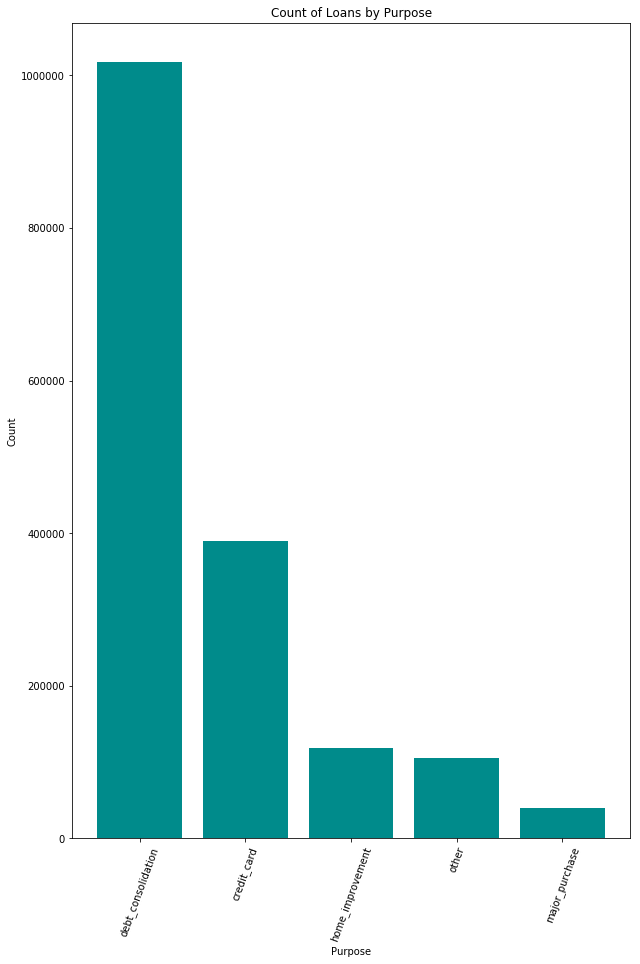

```python
# load_data['addr_state'] = load_data['addr_state'].astype(str)
purpose_loan=load_data[['purpose']].groupby(['purpose'])['purpose'].count().reset_index(name='count').sort_values(['count'],ascending=False).head(5)
print(purpose_loan)


x = np.array(range(len(purpose_loan)))
y = purpose_loan['count']
my_xticks = purpose_loan['purpose']
#plt.xticks(count_code.index, count_code['code'], rotation=90,y='count')
plt.xticks(x, my_xticks)
#plt.plot(x,y)
plt.xticks(rotation=70)
# plt.rcParams["figure.figsize"] = (10,15)
plt.bar(x,y,color='darkcyan')

plt.title('Count of Loans by Purpose')
plt.ylabel('Count')
plt.xlabel('Purpose')

# plt.savefig(os.path.join('Part1','TimeSeries.png'),dpi=100)
#droppingcolumn fintime
plt.show()
plt.clf()
```

```python
load_data.columns
```

```
Index(['loan_amnt', 'funded_amnt', 'funded_amnt_inv', 'term', 'int_rate',
       'installment', 'grade', 'emp_length', 'home_ownership', 'annual_inc',
       ...
       'total_bal_ex_mort', 'total_bc_limit', 'total_il_high_credit_limit',
       'hardship_flag', 'disbursement_method', 'debt_settlement_flag',
       'timestamp', 'issue_year', 'issue_month', 'Risk_Score'],
      dtype='object', length=109)
```

#### Analysis of DTI

Next, we tried to understand the ratio of debt payment by the total debt obligation of all employees by understanding distributionby issue year. Since, this is a ratio it cannot be aggregated further

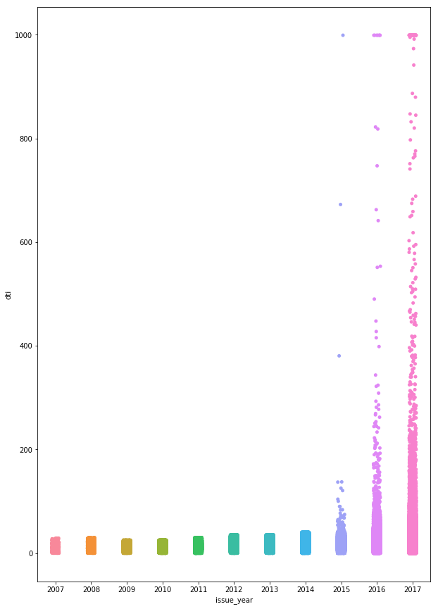

```python
ax = sns.stripplot(x="issue_year", y="dti", data=load_data, jitter=True)
plt.show()
```

```python
df1=load_data[load_data["dti"]<999].groupby(["issue_year"])
print(df1.count())
```

```
            loan_amnt  funded_amnt  funded_amnt_inv    term  int_rate  \
issue_year
2007              603          603              603     603       603
2008             2393         2393             2393    2393      2393
2009             5281         5281             5281    5281      5281
2010            12537        12537            12537   12537     12537
2011            21721        21721            21721   21721     21721
2012            53365        53365            53365   53365     53365
2013           134814       134814           134814  134814    134814
2014           235627       235627           235627  235627    235627
2015           421092       421092           421092  421092    421092
2016           434400       434400           434400  434400    434400
2017           443522       443522           443522  443522    443522

            installment   grade  emp_length  home_ownership  annual_inc  \
```

[output cut: 56 more lines]

#### Analysis of Interest Rate by Term

Analysed the Avereage interest interest rate by term. The mean interest rate is 12 % for laons with a term of 36 months and 16% for a loan with a term of 60 months

```
   term       mean
0  36.0  12.028645
1  60.0  16.145811
```

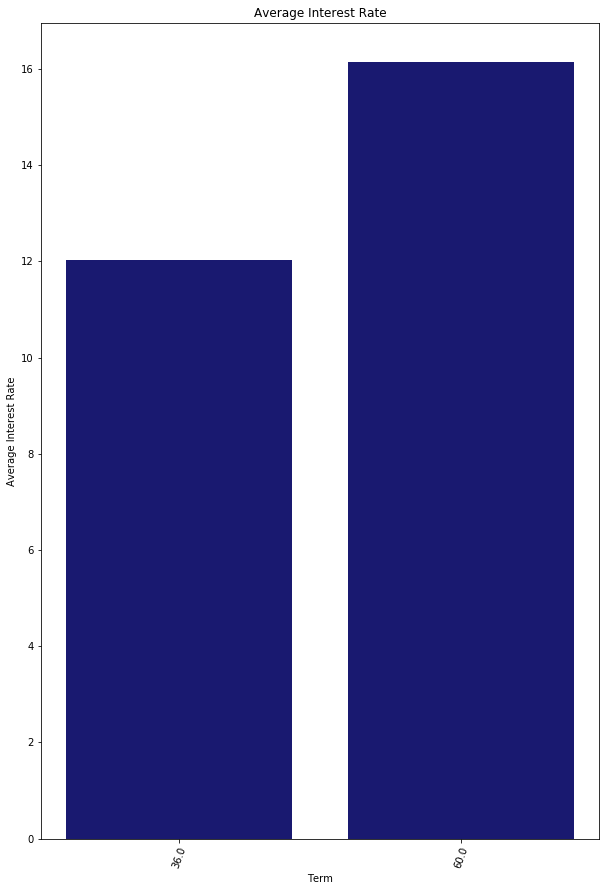

```python
ir_term_trend=load_data[['int_rate','term']].groupby(['term'])['int_rate'].mean().reset_index(name='mean').sort_values(['mean'],ascending=True)
print(ir_term_trend)

x = np.array(range(len(ir_term_trend)))
y = ir_term_trend['mean']
my_xticks = ir_term_trend['term']
#plt.xticks(count_code.index, count_code['code'], rotation=90,y='count')
plt.xticks(x, my_xticks)
#plt.plot(x,y)
plt.xticks(rotation=70)
plt.bar(x,y,color='midnightblue')
plt.title('Average Interest Rate')
plt.ylabel('Average Interest Rate')
plt.xlabel('Term')
# plt.savefig(os.path.join('Part1','TimeSeries.png'),dpi=100)
#droppingcolumn fintime
plt.show()
plt.clf()
```

#### Analysis of Count of Loans by Purpose

```
               purpose    count
3          educational      424
10    renewable_energy     1170
13             wedding     2350
5                house     8706
12            vacation    12024
8               moving    12288
0                  car    19034
11      small_business    20106
7              medical    20866
6       major_purchase    38823
9                other   104420
4     home_improvement   117709
1          credit_card   389266
2   debt_consolidation  1018234
```

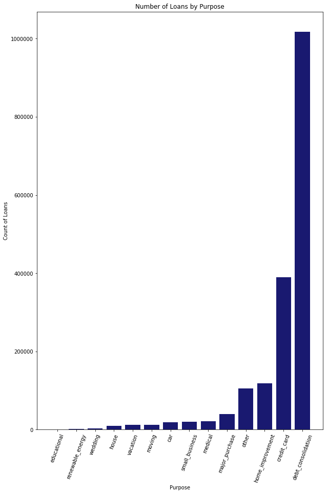

```python
purpose_trend=load_data[['purpose']].groupby(['purpose'])['purpose'].count().reset_index(name='count').sort_values(['count'],ascending=True)
print(purpose_trend)

x = np.array(range(len(purpose_trend)))
y = purpose_trend['count']
my_xticks = purpose_trend['purpose']
#plt.xticks(count_code.index, count_code['code'], rotation=90,y='count')
plt.xticks(x, my_xticks)
#plt.plot(x,y)
plt.xticks(rotation=70)
plt.bar(x,y,color='midnightblue')
plt.title('Number of Loans by Purpose')
plt.ylabel('Count of Loans')
plt.xlabel('Purpose')
# plt.savefig(os.path.join('Part1','TimeSeries.png'),dpi=100)
#droppingcolumn fintime
plt.show()
plt.clf()
```

#### Analysis of Application Type by Interest Rate

We first analysed Application type on the basis of Issue Year and Average Interest Rate . As per the results it is observed that the Join Applications were made in 2015,2016 and 2017.

Next we observed the application type by avaerage interest rate. Joint Applications had a higher interest rate.

```
   application_type  issue_year       mean
0        Individual        2007  11.825108
3        Individual        2010  11.985268
1        Individual        2008  12.061964
4        Individual        2011  12.223365
2        Individual        2009  12.437247
8        Individual        2015  12.596566
9        Individual        2016  13.018822
10       Individual        2017  13.184314
5        Individual        2012  13.637707
7        Individual        2014  13.769482
13        Joint App        2017  13.827025
12        Joint App        2016  14.172563
6        Individual        2013  14.532014
11        Joint App        2015  15.171781
  application_type       mean
0       Individual  13.174264
1        Joint App  13.899023
```

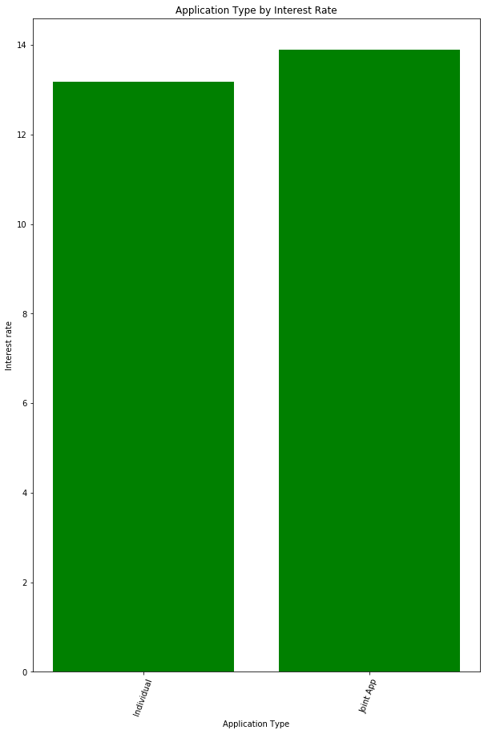

```python
apptype_issueyear_trend=load_data[['application_type','int_rate','issue_year']].groupby(['application_type','issue_year'])['int_rate'].mean().reset_index(name='mean').sort_values(['mean'],ascending=True)
print(apptype_issueyear_trend)

apptype_trend=load_data[['application_type','int_rate']].groupby(['application_type'])['int_rate'].mean().reset_index(name='mean').sort_values(['mean'],ascending=True)
print(apptype_trend)

x = np.array(range(len(apptype_trend)))
y = apptype_trend['mean']
my_xticks = apptype_trend['application_type']
#plt.xticks(count_code.index, count_code['code'], rotation=90,y='count')
plt.xticks(x, my_xticks)
#plt.plot(x,y)
plt.xticks(rotation=70)
plt.bar(x,y,color='green')
plt.title('Application Type by Interest Rate')
plt.ylabel('Interest rate')
plt.xlabel('Application Type')
# plt.savefig(os.path.join('Part1','TimeSeries.png'),dpi=100)
#droppingcolumn fintime
plt.show()
plt.clf()
```

#### Analysis of Employment Length by Interest Rate

```
    emp_length       mean
0            0  13.271612
1            1  13.229564
2            2  13.219682
3            3  13.206205
4            4  13.233250
5            5  13.255881
6            6  13.293617
7            7  13.309493
8            8  13.187865
9            9  13.182221
10          10  13.114228
```

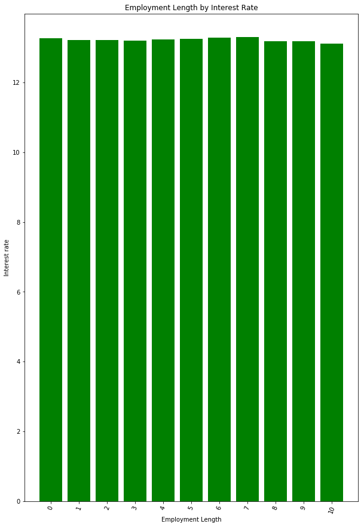

```python
emplen_intrate_trend=load_data[['emp_length','int_rate']].groupby(['emp_length'])['int_rate'].mean().reset_index(name='mean').sort_values(['emp_length'],ascending=True)
print(emplen_intrate_trend)


x = np.array(range(len(emplen_intrate_trend)))
y = emplen_intrate_trend['mean']
my_xticks = emplen_intrate_trend['emp_length']
#plt.xticks(count_code.index, count_code['code'], rotation=90,y='count')
plt.xticks(x, my_xticks)
#plt.plot(x,y)
plt.xticks(rotation=70)
plt.bar(x,y,color='green')
plt.title('Employment Length by Interest Rate')
plt.ylabel('Interest rate')
plt.xlabel('Employment Length')
# plt.savefig(os.path.join('Part1','TimeSeries.png'),dpi=100)
#droppingcolumn fintime
plt.show()
plt.clf()
```